# BPB3: BayesPI-BAR version 3 package User Guide

# Demo6:

# Applying bpb3 on Genome-wide Sequencing Data of Skin Cancer Patients by Using Clustered-PWMs with Two-levels Approach

**Running the first-level analysis by using a predefined bpb3 parameter configure file:**  
bpb3_clusterPWM_config_skin_cancer.py

**Running the second-level analysis by using bpb3 command lines:**  
run_selected_pwms_from_clusterPWM_cmd_skin_cancer.py

## Aim and pipeline flow

In demo6, the same two-levels approach as demo5 is used to predict TF binding affinity changes that are significantly altered by mutations. This time, a predefined parameter configure is used instead of bpb3 command lines in the demo5, for computing the first-level analysis of clustered PWMs. The parameter configure file can be directly loaded to bpb3 by the “run_pipeline” module to complete the analysis. It is worthy to note that both patient mutation data and gene expression profiles are from the same follicular lymphoma patients in demo5, but they are not matched in skin cancer patients demo6. For example, there are 50 and 20 patients’ mutation data and gene expression data in demo6, respectively.

In the first-level analysis (bpb3_clusterPWM_config_skin_cancer.py): ~737 clustered PWMs generated by abc4pwm package are used in the calculation, the computations (e.g., applying clustered PWMs on foreground and background calculations) are similar to that in the Demo5, but all tasks are performed by directly uploading a parameter configure file to bpb3 package.

In the second-level analysis (run_selected_pwms_from_clusterPWM_cmd_skin_cancer.py): the top ranked N (e.g., 25) clustered PWMs for each mutation block are selected, then the PWMs grouped in these clusters (e.g., ~150 PWMs) are extracted and used to predict TF binding affinity changes that are significantly altered by mutation block in patients. In this way, more detailed information of TF binding and mutation changes will be revealed than that in the first-level analysis.

## Run job

**Run job**  
final_demo_data/demo6_skin_cancer_small/sbatch job_bpb3

```bash
sbatch job_bpb3
```

**Job script:**

```bash
#run bpb3 by clustered PWMs from abc4pwm -- first level analysis
bpb3 run_pipeline --import_bpb3_config bpb3_clusterPWM_config_skin_cancer.py

#run bpb3 on selected PWMS from clustered PWMs - second level analysis
python run_selected_pwms_from_clusterPWM_cmd_skin_cancer.py
```

**Main process**  
The main processes are stored in Slurm file, example:

```
######################################################
# The first-level analysis (bpb3_clusterPWM_config_skin_cancer.py)
######################################################
T-test

Export at  final_demo_data/demo6_skin_cancer_small/out/regions.bed
Read , final_demo_data/demo6_skin_cancer_small/out/mussd_blocks/blocks_summary.tsv
Adjust P-values by Bonferroni correction in high mutation blocks test
Background block size will be equal to median significant block size: 94

Mutation count distribution:
     number of mutations     probability
     1                     1.0

36 PWMs are chosen for background model based on foreground rankings (max rank is 10 )

Calculating delta-dbA values...
The result folder, final_demo_data/demo6_skin_cancer_small/out/background/bayespi_bar_result/ddba

Integrating delta-dbA values across chemical potentials using mean_ddba ...
Computing PWM rankings for each variant...
The result folder, final_demo_data/demo6_skin_cancer_small/out/background/bayespi_bar_result/rankings
final_demo_data/demo6_skin_cancer_small/out/background/bayespi_bar_result/ddba/ddba_integrated_using_mean_ddba.tsv : 1000 mutations,  36 PWMs
final_demo_data/demo6_skin_cancer_small/out/foreground/block_0_5_1295205_1295250/ddba/ddba_integrated_using_mean_ddba.tsv : 15 mutations,  736 PWMs
736 total PWMs

Positive PWMs at 0.05 bonferroni significance:
     abc4pwm_uncertain_pwms~1_ETS_known6_from_GABP_1_from_GABP_transfac_M00341-Tryptophan.mlp   bonferroni p: 6.945685238131073e-61     #cases: 14 / 15
     abc4pwm_uncertain_pwms~4_NFE2L2_1_from_Nrf-2_transfac_M00108-bZIP.mlp  bonferroni p: 3.142987358554262e-48     #cases: 15 / 15
     abc4pwm_uncertain_pwms~0_HINFP_2_from_HINFP1_jolma_full_M16-C2H2_ZF.mlp    bonferroni p: 3.5631092330149903e-47    #cases: 15 / 15
     abc4pwm_uncertain_pwms~1_ETV5_1_from_ETV5_jolma_DBD_M106-Tryptophan.mlp    bonferroni p: 7.180659877108394e-32     #cases: 14 / 15
     abc4pwm_quality_assessed_out_seed5~Tryptophan~out~11~repres~11_rep.mlp     bonferroni p: 1.0894205547547532e-21    #cases: 15 / 15
     abc4pwm_uncertain_pwms~6_CACBP_1_from_CAC-binding-protein_transfac_M00720-Unknown.mlp  bonferroni p: 1.02546400905484e-20  #cases: 14 / 15
     abc4pwm_uncertain_pwms~3_ETS_known7_from_ELK1_3_from_ELK1_jaspar_MA0028.1-Tryptophan.mlp   bonferroni p: 4.9904460496088324e-20    #cases: 14 / 15
     abc4pwm_quality_assessed_out_seed5~Tryptophan~out~3~repres~3_rep.mlp   bonferroni p: 3.2657953010190567e-19    #cases: 14 / 15
     abc4pwm_uncertain_pwms~0_ELF5_1_from_ELF5_jaspar_MA0136.1-Tryptophan.mlp   bonferroni p: 7.611188245034236e-18     #cases: 15 / 15
     abc4pwm_uncertain_pwms~SP1_known1_from_SP1_1_from_Sp1_transfac_M00008-NonO_domain_factors.mlp  bonferroni p: 9.673972928791537e-18     #cases: 15 / 15
     abc4pwm_uncertain_pwms~3_STAT_known7_from_STAT1_2_from_STAT1_transfac_M00492-STAT.mlp  bonferroni p: 1.0023060855044762e-17    #cases: 14 / 15
     abc4pwm_quality_assessed_out_seed5~Tryptophan~out~4~repres~4_rep.mlp   bonferroni p: 1.6319946266243857e-17    #cases: 15 / 15
     abc4pwm_uncertain_pwms~14_MAZ_1_from_MAZ_transfac_M00649-C2H2_ZF.mlp   bonferroni p: 3.710873750561869e-16     #cases: 14 / 15
```

[output cut: 80 more lines]

```
     6_IRF_known4_from_IRF7_1_from_IRF-7_transfac_M00453-Tryptophan.mlp     uncorrected p: 7.423894305194403e-23    #cases: 15 / 15
     1_HSF4_1_from_HSF4_jolma_DBD_M143-Heat_shock_factors.mlp   uncorrected p: 2.7743502002688305e-21#cases: 11 / 15
     6_SPIB_1_from_SPIB_jaspar_MA0081.1-Tryptophan.mlp  uncorrected p: 8.115294465662671e-21    #cases: 15 / 15
     HMGA1_1_from_HMG-IY_transfac_M00750-A.T_hook_factors.mlp   uncorrected p: 1.2029908160322761e-20#cases: 15 / 15
     1_HSF_known4_from_HSF1_4_from_HSF1_jolma_DBD_M140-Heat_shock_factors.mlp   uncorrected p: 3.496597094130855e-18    #cases: 11 / 15
     AIRE_1_from_AIRE_transfac_M00999-SAND.mlp  uncorrected p: 1.1462268114455671e-17   #cases: 10 / 15
     16_FOXJ3_2_from_FOXJ3_jolma_DBD_M419-Forkhead.mlp  uncorrected p: 2.315179165383709e-17    #cases: 15 / 15
     2_THRB_2_from_THRB_jolma_DBD_M729-Nuclear_receptor.mlp     uncorrected p: 3.109626961362597e-16 #cases: 10 / 15
     1_SRY_1_from_SRY_transfac_M00148-HMG.mlp   uncorrected p: 9.013787070118551e-16    #cases: 15 / 15
     22_SP4_2_from_SP4_jolma_full_M31-C2H2_ZF.mlp   uncorrected p: 6.258114214572136e-08    #cases: 5 / 15
     41_ISL2_1_from_Isl2_bulyk_cell08-3430.1-Homeodomain.mlp    uncorrected p: 0.0022778388754498167 #cases: 4 / 15

Log file: ../../final_demo_data/demo6_skin_cancer_small/bpb3_by_selected_pwm_from_cluster4pwm_bpb3.log_1658094943.30313
block_0_5_1295205_1295250 :
Filtering results by gene expression for block block_0_5_1295205_1295250 ...
```

**Data input**

```
# Gene expression data of control samples:
final_demo_data/demo6_skin_cancer_small/normal_melanocyte_rnaseq/
|-- SRR1182316.sam.bam.sorted.bam.only_counts.tsv
|-- SRR1182317.sam.bam.sorted.bam.only_counts.tsv
|-- SRR1182319.sam.bam.sorted.bam.only_counts.tsv
`-- SRR1182320.sam.bam.sorted.bam.only_counts.tsv

# Patient specific mutations (vcf format) and gene expression data (*_expression.tsv)
final_demo_data/demo6_skin_cancer_small/patient_data/
patient_data/
|-- DO218840
|   `-- icgc_mutations_on_5.tsv
|-- DO218841
|   `-- icgc_mutations_on_5.tsv
|-- DO218847
|-- DO218854
|-- DO218856
|-- DO218857
|-- DO218866
|-- DO218874
|-- DO218876
|-- DO218886
|-- DO218890
|-- DO218902
|-- DO219873
|-- DO219878
|-- DO220844
|-- DO220845
|-- DO220846
|-- DO220848
|-- DO220850
|-- DO220853
|-- DO220868
|-- DO220872
|-- DO220873
|-- DO220875
|-- DO220880
|-- DO220883
|-- DO220887
|-- DO220889
```

[output cut: 57 more lines]

```
│       │   ├── 0_AP1_known1_from_AP1_2_from_AP-1_transfac_M00172-C2CH_THAP_type_ZF.mlp
│       │   ├── 0_AP1_known2_from_AP1_3_from_AP-1_transfac_M00173-C2CH_THAP_type_ZF.mlp
│       │   ├── 0_AP1_known4_from_AP1_5_from_AP-1_transfac_M00188-C2CH_THAP_type_ZF.mlp
│       │   └── repres
│       │       └── 0_rep.mlp
│       ├── 1
│       │   ├── 1_AP1_known10_from_AP1_1_from_AP1_jaspar_MA0099.2-C2CH_THAP_type_ZF.mlp
│       │   ├── 1_AP1_known7_from_AP1_8_from_AP-1_transfac_M00924-C2CH_THAP_type_ZF.mlp
│       │   ├── 1_AP1_known9_from_AP1_10_from_AP-1_transfac_M00926-C2CH_THAP_type_ZF.mlp
│       │   └── repres
│       │       └── 1_rep.mlp
│       ├── 2
│       │   ├── 2_AP1_known5_from_AP1_6_from_AP-1_transfac_M00199-C2CH_THAP_type_ZF.mlp
│       │   ├── 2_AP1_known8_from_AP1_9_from_AP-1_transfac_M00925-C2CH_THAP_type_ZF.mlp
 ...
```

**Data output**

```
# Results of the first-level analysis:
final_demo_data/demo6*/out/
|-- background
|   |-- background_mutation_pos.bed
|   |-- bayespi_bar_result
|   |-- possible_background_blocks_restricted.bed
|   |-- possible_background_block_starts.bed
|   |-- randomly_selected_blocks_alt.fasta
|   |-- randomly_selected_blocks.bed
|   `-- randomly_selected_blocks_ref.fasta
|-- demo6_skin_cancer_bpb3.log_1654246183.9757624
|-- demo6_skin_cancer_bpb3.log_1658091786.0996118
|-- differentially_expressed_genes.txt
|-- foreground
|   `-- block_0_5_1295205_1295250
|-- make_background.sh
|-- mussd_blocks
|   |-- block_0_5_1295205_1295250_alt.fasta
|   |-- block_0_5_1295205_1295250.bed
|   |-- block_0_5_1295205_1295250_mutations.tsv
|   |-- block_0_5_1295205_1295250_ref.fasta
|   |-- blocks_summary.tsv
|   |-- mutations_in_regions.tsv
|   |-- mutations_summary.tsv
|   `-- patients_summary.tsv
|-- normal_median_patient_rpkm.tsv
|-- regions.bed
|-- run_mussd.sh
|-- significant_blocks.txt
`-- tumor_median_patient_rpkm.tsv

# Results of the second-level analysis:
final_demo_data/demo6_*/bpb3_by_selected_pwm_from_cluster4pwm/
`-- block_0_5_1295205_1295250
    |-- ddba
    |   |-- ddba_integrated_using_mean_ddba.tsv
    |   |-- ddba_integrated_using_pca.tsv
    |   |-- potential_-10_ddba.tsv
    |   |-- potential_-13_ddba.tsv
    |   |-- potential_-15_ddba.tsv
```

[output cut: 9 more lines]

```
    |   |-- block_0_5_1295205_1295250_patient_25_5_1295179_1295274_ranking.tsv
    |   |-- block_0_5_1295205_1295250_patient_27_5_1295179_1295274_ranking.tsv
    |   |-- block_0_5_1295205_1295250_patient_32_5_1295179_1295274_ranking.tsv
    |   |-- block_0_5_1295205_1295250_patient_34_5_1295179_1295274_ranking.tsv
    |   |-- block_0_5_1295205_1295250_patient_39_5_1295179_1295274_ranking.tsv
    |   |-- block_0_5_1295205_1295250_patient_40_5_1295179_1295274_ranking.tsv
    |   |-- block_0_5_1295205_1295250_patient_41_5_1295179_1295274_ranking.tsv
    |   |-- block_0_5_1295205_1295250_patient_51_5_1295179_1295274_ranking.tsv
    |   |-- block_0_5_1295205_1295250_patient_6_5_1295179_1295274_ranking.tsv
    |   `-- block_0_5_1295205_1295250_patient_7_5_1295179_1295274_ranking.tsv
    |-- result_filtered.tsv
    |-- result_gene_names.tsv
    |-- result_plot.png
    |-- result.tsv
    `-- snp_id2snp.tsv
```

**Predicted TFs with significant binding affinity changes due to mutation block**  
**1. Output by the first-level analysis:**

**Table 1.** One example of final results from bpb3 when using the first-level analysis to predict TFs bind affinity changes at promoter regions of differential expressed genes (DEG):  
final_demo_data/demo6_skin_cancer_small/out/foreground/block_0_5_1295205_1295250/result_filtered.tsv

Here, the binding affinity of ETS family related transcription factors (e.g., ETS, ETV5, and SP1 et. al.) were positively affected by a mutation block located in the promoter of TERT gene. This result matches to previous publication [Batmanov K et. al., 2019, Front Genet](https://www.frontiersin.org/articles/10.3389/fgene.2019.00282/full)

| direction | pwm_name | bonferroni_p | affected_cases | total_cases |
| --- | --- | --- | --- | --- |
| Positive | abc4pwm_uncertain_pwms~1_ETS_known6_from_GABP_1_from_GABP_transfac_M00341-Tryptophan.mlp | 0 | 14 | 15 |
| Positive | abc4pwm_uncertain_pwms~4_NFE2L2_1_from_Nrf-2_transfac_M00108-bZIP.mlp | 0 | 15 | 15 |
| Positive | abc4pwm_uncertain_pwms~0_HINFP_2_from_HINFP1_jolma_full_M16-C2H2_ZF.mlp | 0 | 15 | 15 |
| Positive | abc4pwm_uncertain_pwms~1_ETV5_1_from_ETV5_jolma_DBD_M106-Tryptophan.mlp | 0 | 14 | 15 |
| Positive | abc4pwm_uncertain_pwms~3_ETS_known7_from_ELK1_3_from_ELK1_jaspar_MA0028.1-Tryptophan.mlp | 0 | 14 | 15 |
| Positive | abc4pwm_uncertain_pwms~SP1_known1_from_SP1_1_from_Sp1_transfac_M00008-NonO_domain_factors.mlp | 0 | 15 | 15 |
| Positive | abc4pwm_uncertain_pwms~3_STAT_known7_from_STAT1_2_from_STAT1_transfac_M00492-STAT.mlp | 0 | 14 | 15 |
| Positive | abc4pwm_uncertain_pwms~14_MAZ_1_from_MAZ_transfac_M00649-C2H2_ZF.mlp | 0 | 14 | 15 |
| Positive | abc4pwm_quality_assessed_out_seed5<sub>STAT</sub>out<sub>3</sub>repres~3_rep.mlp | 0 | 15 | 15 |
| Positive | abc4pwm_uncertain_pwms~5_SPI1_known2_from_SPI1_2_from_SPI1_jaspar_MA0080.2-Tryptophan.mlp | 0 | 15 | 15 |
| Positive | abc4pwm_uncertain_pwms~7_ETS_known8_from_ETS1_3_from_ETS1_jaspar_MA0098.1-Tryptophan.mlp | 0 | 14 | 15 |
| Positive | abc4pwm_uncertain_pwms~SP1_known8_from_SP1_7_from_SP1_jolma_DBD_M29-NonO_domain_factors.mlp | 0 | 14 | 15 |
| Positive | abc4pwm_uncertain_pwms~SP1_known4_from_SP1_3_from_Sp1_transfac_M00931-NonO_domain_factors.mlp | 0 | 14 | 15 |
| Positive | abc4pwm_uncertain_pwms~SP1_known6_from_SP1_5_from_Sp1_transfac_M00933-NonO_domain_factors.mlp | 0 | 14 | 15 |
| Negative | abc4pwm_uncertain_pwms~6_E2F_known21_from_E2F1_19_from_E2F-1_transfac_M00940-Forkhead.mlp | 0 | 15 | 15 |
| Negative | abc4pwm_uncertain_pwms~6_HOXD9_3_from_Hoxd9_jolma_DBD_M561-Homeodomain.mlp | 0 | 15 | 15 |
| Negative | abc4pwm_quality_assessed_out_seed5<sub>SMAD</sub>out<sub>2</sub>repres~2_rep.mlp | 0 | 15 | 15 |
| Negative | abc4pwm_uncertain_pwms~16_FOXJ3_2_from_FOXJ3_jolma_DBD_M419-Forkhead.mlp | 0 | 15 | 15 |

**Figure 1.** Predicted TFs with significant binding affinity changes due to mutation block (first-level analysis)  
File in: final_demo_data/demo6_skin_cancer_small/out/foreground/block_0_5_1295205_1295250/result_plot.png

The result_plot shows TFs with significant binding affinity changes due to a mutation block (block_0_5_1295205_1295250) located in promoter of gene TERT (Figure 2). The binding affinity of identified transcript factors, including ETS and SP1, were positively affected by this mutation block in 15 out of 50 patients.

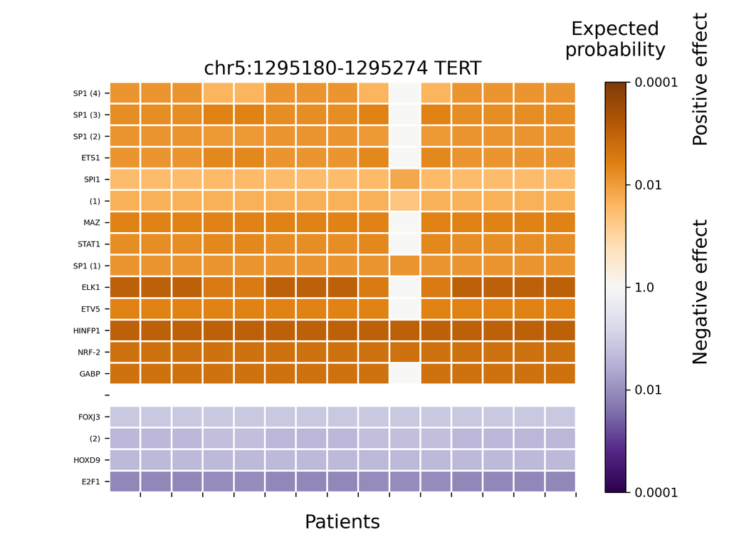

(Figure 1)

**Figure 2.** A genome browser view of mutation block (block_0_5_1295205_1295250) in the promoter region of gene TERT in chr5.

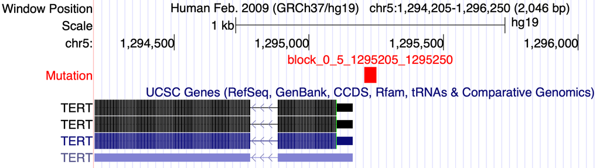

(Figure 2)

**2. Output by the second-level analysis:**  
**Table 2.** One example of final results from the second-level analysis for predicting TFs bind affinity changes at promoter regions of differential expressed genes (DEG).

In agreeing with the first-level analysis, the binding affinity of a number of ETS family transcription factors (e.g., ETS, ETV5, and SP1 et. al.) were significantly increased due to the mutation block in promoter of gene TERT.

[output not shown]

**Figure 3.** Predicted TFs with significant binding affinity changes due to mutation block (second-level analysis)  
File in: final_demo_data/demo6_skin_cancer_small/bpb3_by_selected_pwm_from_cluster4pwm/block_0_5_1295205_1295250/result_plot.png

The result_plot shows TFs with significant binding affinity changes due to a mutation block (block_0_5_1295205_1295250) located at promoter of TERT gene. Similar to the first-level analysis, the binding affinity of ETS family related transcript factors (e.g., ETS, ETV5, and SP1 et al) were significantly increased (orange color) that matches to previous publication [Batmanov K et. al., 2019, Front Genet](https://www.frontiersin.org/articles/10.3389/fgene.2019.00282/full). Importantly, more ETS related TFs were identified in the second level analysis.

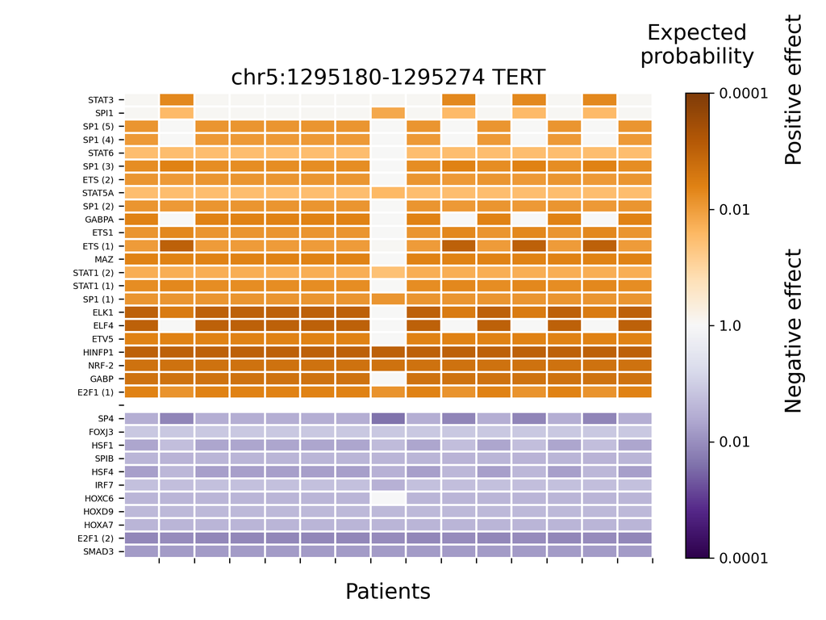

(Figure 3)

## Python code I (first-level analysis): a bpb3 parameter configure file that can be directly loaded to the package

bpb3_clusterPWM_config_skin_cancer.py

```python
import os
import glob
from bpb3.script.script_high.other import common
import time


#this is the first level analysis - apply bayespi-bar on pwms of all clusreted PWMs to evaluate their significant TF binding affinity changes
#due to mutations, where representative motif/cluster mean of PWMs were used.

###########Setup main Path ################
#Project Output path
out_data_folder = os.path.abspath("../../final_demo_data/demo6_skin_cancer_small/out")
patient_data_folder = os.path.join(out_data_folder,'../', "patient_data")
normal_rnaseq_folder = os.path.join(out_data_folder,'../', "normal_melanocyte_rnaseq")
project_name='demo6_skin_cancer'

#Genome path
genome_folder=os.path.abspath("../../final_demo_data/genome_data/hg19")
genome_fasta_file= os.path.join(genome_folder, "human_g1k_v37_decoy.fasta")
gene_annotation_file= os.path.join(genome_folder, "gencode.v19.annotation.gtf")

# output folders
foreground_folder = os.path.join(out_data_folder, "foreground")
background_folder = os.path.join(out_data_folder, "background")
background_pwm_folder = os.path.join(out_data_folder, "pwm_for_background")
mussd_result_folder = os.path.join(out_data_folder, "mussd_blocks")

#Input gene expression folder
#gene expression file name postprefix in folder normal_rnaseq_folder
normal_count_files_postprefix="*.only_counts.tsv"

#gene length
gene_length_file = os.path.join(genome_folder, "gene_lengths.tsv")

#gene expression file name postprefix in folder patient_data_folder
donor_count_files_postprefix="other*/*_expression.tsv"

#0.  make cluster pwms Here is the only difference if input PWMs are clustered or not!
#  Generate tempary pwms based on clustered and uncertain clustered PWMs ############
in_clustered_pwms_path=os.path.join(out_data_folder,'../')
in_clustered_pwms_folder_name='abc4pwm_quality_assessed_out_seed5'
in_uncertain_pwms_folder_name='abc4pwm_uncertain_pwms'
out_tmp_pwms_folder_name='tmp_pwm'

# folder with PWM models for TF binding affinity
pwm_folder=os.path.join(in_clustered_pwms_path,out_tmp_pwms_folder_name)


###########Setup Pipeline parameters #########33
#1. Differential gene expression options
differentially_expressed_genes_file = os.path.join(out_data_folder, "differentially_expressed_genes.txt")
group1_str='tumor'
group2_str='normal'
#Export file path
group1_median_rpkm_file = os.path.join(out_data_folder, group1_str + "_median_patient_rpkm.tsv")
group2_median_rpkm_file = os.path.join(out_data_folder, group2_str +"_median_patient_rpkm.tsv")

# maximum Kolmogorov-Smirnov test P value to consider genes as differentially expressed
differential_expression_p = 0.05
# whether to do quantile normalization of RPKM values, True or False
differential_expression_quantile_normalization = True
# whether to do log transformation of RPKM values, True or False
differential_expression_log_transform = True
# whether to do z-score transformation of RPKM values, True or False
differential_expression_z_score_transform = False
# minimum fold change of [quantile normalized] RPKM to consider genes as differentially expressed. None to disable
differential_expression_min_fold_change = None
#export full expression data
isExportAll = True
#test_method 1 for T-test
test_method=1
#minimum median RPKM in each group
minimum_median_RPKM=0  #1.0

# 2. Region of interest selection options
# number of base pairs to take upstream of TSS
upstream_size = 2000
# number of base pairs to take downstream of TSS
downstream_size = 100
#Export file path
regions_file = os.path.join(out_data_folder, "regions.bed")

# Here, if we do not use bpb3 function to extract a specified TSS regions, then we can manually input a bed format region file
# for example, using enhancer regions overlapping with Differential Methylation Regions for DNA muatation enrichment and the TF binding affinity change significance test
#regions_file='../../public_data/mr_test/in/mr_intersect_enhancer_regions_chr18noChr.tsv'

# 3. MuSSD options
# minimum number of patients in a hot mutation region
min_patients_in_block = 5
# minimum number of mutations in a hot mutation region
min_block_size = 10
# maximum distance between mutations in a hot mutation region
cluster_distance = 30
block_distance=500
# number of base pairs to add to the left and right side of a mutation block when extracting sequences
block_flank = 25


#4. P values for significant muation blocks
p_value_for_significant_blocks=0.001
mussd_command_file=os.path.join(out_data_folder, 'run_mussd.sh')
pval_correction=True

#patient mutation file names under folder patient_data_folder
patient_mut_files_postprefix="DO*/icgc_mutations*.tsv"

#Export file path of significant mutation blocks
significant_blocks_file = os.path.join(out_data_folder, "significant_blocks.txt")

# 5. BayesPI-BAR options
# chemical potentials to use
chemical_potentials = "none -10 -13 -15 -18 -20"
# sequence shuffling iterations for dbA calculation
shuffling_iterations = 10000
#Parallel option path
parallel_options_file = os.path.abspath(os.path.join(os.path.dirname(__file__), "parallel_options.txt"))
max_ranking_for_foreground=30
#assume both forground and background ddba are already exists!
start_from_integration=False

# 6. Background model options
# max rank of a PWM file in the foreground results to include in the background model
max_ranking_for_background = 10
resampling_iterations = 10
gene_samples = 100
background_shuffling_iterations = 1000
background_command_file = os.path.join(out_data_folder, "make_background.sh")

# 7. mutation signature definition for generating background mutations, set to None to disable
mutation_signature_file = None  # "../../data/signature_7.tsv"
# set to True to use tumor mutations from patients as background mutations, False otherwise.
# This and the mutation signature are mutually exclusive.
# In both are disabled, uniform mutations will be generated
tumor_mutations_as_background = True

# Results selection options for significant affinity changes
# P value for ranksum test in the output
affinity_change_p_value = 0.05
pval_correction4affinity=True
#signifcant block parameters
max_ranking_for_significant_blocks= 30

#8. True or False parameters to run the bpb3, by either enable  or disable one of bpb3 steps

#step 1. differential expression analysis
runDiffExp= True

#step 2: region extraction
runRegionsFile= True

#step 3: mussd mutation block detection
runMussd= True

#step 4: highly mutated mutation block test
runHighMutBlocks= True

#step 5: do foreground bayespi-bar calculation
runBayesPiBAR= True

#step 6: do background bayespi-bar calcuation
runBackgroundModel= True

#step 7: do TF affinity change significance test
runBlockSignificance= True

#step 8: filter TF by gene expression level
filterTFbyGene=True

#step 9: plot heatmap for TFs with significaly changed binding affinity
isPlot=True

#step 10: remove temporary files in both foreground and background calculations
runRemoveTempFile= True

#option step: if the input PWMs are clustered PWMs from abc4pwm, then this option shall be True
runCluster4PWM=True
```

## Python code II (second-level analysis): selected the top 25 clustered PWMs from the first-level analysis for further study.

run_selected_pwms_from_clusterPWM_cmd_skin_cancer.py

```python
import os
from bpb3.script.script_high.other import common
import time

#this is the second level analysis - apply bayespi-bar on selected top N pwms from clusreted PWMs that show significant
#TF binding affinity changes due to mutations, where individual PWM is extracted from clustered PWMs if they are selected in the top N.

#Input data folder, where contains the result of first level analysis based on clustered PWMs and mutation blocks
in_data_folder='../../final_demo_data/demo6_skin_cancer_small/'
mussd_out_data_folder=os.path.join(in_data_folder, 'out')
significant_blocks_file = os.path.join(mussd_out_data_folder, "significant_blocks.txt")

#Parameter for cluster4pwm , or result of clustered PWMs from abc4pwm
in_clustered_pwms_folder_name='abc4pwm_quality_assessed_out_seed5'
in_uncertain_pwms_folder_name='abc4pwm_uncertain_pwms'

#project name or file folder for storing outpu results.
project_name='bpb3_by_selected_pwm_from_cluster4pwm'
out_project_folder=os.path.join(in_data_folder, project_name)

#parameter for tumor or normal expression data which will be used for filtering TF based on expression levels
group1_str='tumor'
group2_str='normal'
#Export file path
group1_median_rpkm_file = os.path.join(mussd_out_data_folder, group1_str + "_median_patient_rpkm.tsv")
group2_median_rpkm_file = os.path.join(mussd_out_data_folder, group2_str +"_median_patient_rpkm.tsv")

#parameter for bpb3 mussd
# output folders for mussd
mussd_result_folder=os.path.join(mussd_out_data_folder, 'mussd_blocks')

#parameter for storing selected PWMs from the top N PWMs from the result of first level analysis based on clustered PWMs
foreground_folder = os.path.join(in_data_folder,project_name )
background_folder = os.path.join(in_data_folder, "background")
background_pwm_folder = os.path.join(in_data_folder, "pwm_for_background")

#parameter for genome path, selecte region information and background
background_command_file= os.path.join(in_data_folder, "make_background.sh")
genome_folder=os.path.abspath("../../final_demo_data/genome_data/hg19")
genome_fasta_file =os.path.join(genome_folder, "human_g1k_v37_decoy.fasta")
regions_file= os.path.join(mussd_out_data_folder, "regions.bed")

#path for pwms selected from the top N PWMs of results of first level analysis based on clustered PWMs
selected_pwm_folder=os.path.join(in_data_folder,'selected_pwm')

#step 1. parameter for bayes-pi-bar foreground calculation
shuffling_iterations=10000
random_seed=1
chemical_potentials= "none -10 -13 -15 -18 -20"
parallel_options_file= os.path.abspath(os.path.join(os.path.dirname(__file__), "parallel_options.txt"))
significant_block_tags = frozenset(common.read_lines(significant_blocks_file))
#select the top N ranked TFs from results of first level analysis based on clustered PWMs
top_ranked_TF_from_clusteredPWM=25


#step 2. bayes-pi-bar background model parameters
background_shuffling_iterations=1000
resampling_iterations=10
gene_samples=100

#step 3. mutation signature definition for generating background mutations, set to None to disable
mutation_signature_file=None
# set to True to use tumor mutations from patients as background mutations, False otherwise.
# This and the mutation signature are mutually exclusive.
# In both are disabled, uniform mutations will be generated
tumor_mutations_as_background=True
max_ranking_for_background=15

#signifcant block parameters
max_ranking_for_significant_blocks= 25
affinity_change_p_value=0.01
pval_correction4affinity=False


logging=common.setup_logger(in_data_folder, project_name, time.time())

##assume both forground and background ddba are already exists!
#this  works for foreground as skip_dba_calculation in bayes-pi-bar
start_from_integration=False

#step 1: do foreground bayespi-bar calculation for selected PWMs
runBayesPiBar4selectedPwms=True

#step 2: do background bayespi-bar calcuation for selected PWMs
runBackgroundModel=True

#step 3: do TF affinity change significance test for selected PWMs
runBlockSignificance=True

#step 4: filter TF by gene expression level and plot heatmaps
filterTFbyGene=True

#step 5: remove temporary files in both foreground and background calculations
runRemoveTempFile=True

############Below are calculations for PWMs selected from clustered PWMs###############
if runBayesPiBar4selectedPwms:
 #loop in each block for computing ddba
 for block_name in significant_block_tags :
  ref_seq=os.path.join(mussd_out_data_folder,'mussd_blocks/'+block_name + '_ref.fasta')
  alt_seq=os.path.join(mussd_out_data_folder,'mussd_blocks/'+block_name + '_alt.fasta')
  block_res_folder=os.path.join(mussd_out_data_folder,'foreground/'+ block_name ,'rankings')

  #collect all mlp in ranking results
  #1. perform bayespi_bar on selected pwms from top ranked TF clusters
  logging.info("")
  logging.info("Step 1: computing the foreground model for selected PWMs from clusters")
  cmd= 'bpb3 bpb3selectedPWM --cluster_out_path '  + in_data_folder + \
        ' --bpb3_out_path ' + block_res_folder  + \
        ' --in_fileString4clustered_pwm ' + in_clustered_pwms_folder_name  + \
        ' --project_name ' + project_name + \
        ' --output_folder ' + block_name + \
        ' --in_fileString4uncertain_pwm '+ in_uncertain_pwms_folder_name + \
        ' --in_separateString4file '+ str("\'~\'") + \
        ' --in_topRank_cutoff ' + str(top_ranked_TF_from_clusteredPWM) + \
        ' --in_seq_ref_file ' + ref_seq +\
        ' --in_seq_alt_file ' + alt_seq +\
        ' --iterations ' + str(shuffling_iterations) +  \
        ' --max_rank ' + str(top_ranked_TF_from_clusteredPWM) + \
        ' --seed ' + str(random_seed) + \
        ' --clean_tmp ' * runRemoveTempFile + \
        ' --skip_dba_calculation ' * start_from_integration + \
        ' --chemical_potentials ' + chemical_potentials +\
        ' --export_selected_pwms ' + \
        ' --p_value_cutoff ' +'0.1' +  ' --integration pca' + \
         ' @' +  parallel_options_file
  result_code=os.system(cmd)
  if result_code !=0:
    logging.info("bpb3selectedPWM failed, see message in the console to find reason.")
    exit(1)
  logging.info('Export at %s , %s ', os.path.join(in_data_folder,project_name,block_name), block_name )
else:
  logging.info("Skip step 1: computing the foreground model for selected PWMs from clusters")
```

```python
if runBackgroundModel:
   # 2. Compute the background for PWMs selected from clustered PWMs
   logging.info("")
   logging.info("Step 2: Computing the background model for selected PWMs from clusters")
   logging.info("Creating shell file with the command to compute the background: %s", background_command_file)
   result_code = os.system("bpb3 choose_background_parameters " +
                            " --blocks_folder " + mussd_result_folder +
                            " --foreground_folder " + foreground_folder +
                            " --background_pwm_folder " + background_pwm_folder +
                            " --output_file " + background_command_file +
                            " --block_ids " + " ".join(significant_block_tags) +
                            " --genome " + genome_fasta_file +
                            " --regions " + regions_file +
                            " --pwm_folder " + selected_pwm_folder +
                            " --iterations " + str(background_shuffling_iterations) +
                            " --chemical_potentials " + chemical_potentials +
                            " --background_output_folder " + background_folder +
                            " --block_resample_iterations " + str(resampling_iterations) +
                            " --block_samples_to_take " + str(gene_samples) +
                            " --reuse_output" +
                            " --start_from_integration" * start_from_integration +
                            " --max_rank " + str(max_ranking_for_background) +
                            ((" --mutation_signature " + mutation_signature_file)
                             if mutation_signature_file is not None else "") +
                            (" --background_mutations %s" %
                             os.path.join(mussd_result_folder, "mutations_in_regions.tsv")) *
                            tumor_mutations_as_background +
                            " @" + parallel_options_file)

   if result_code !=0:
       logging.info("Error in choose background parameters ")
       exit(1)

   logging.info('Export at %s ', background_command_file )

   if os.path.exists(background_folder):
      logging.info("The folder with background output already exists. The background computation script will now "
                     "check its consistency and recompute the broken or missing data")
   else:
      logging.info("The background computation script will now compute the background delta-dbA score distributions %s ", background_command_file)

   result_code = os.system("bash " + background_command_file)
   if result_code != 0:
     logging.info("Background model computation failed. See messages in the console to find what went wrong.")
     exit(1)

   logging.info("Export at %s ", background_folder)

else:
 logging.info('Skip step 2 background_computation %s ', background_folder)



if runBlockSignificance:
 # 3. Run significance tests for TF affinity changes between foreground and background model
 logging.info("")
 logging.info("Step 3: Significance tests will now be computed comparing background and foreground delta-dbA "
                 "distributions for each PWM in each mutation block")

 for block_tag in significant_block_tags:
        block_folder = os.path.join(foreground_folder, block_tag)
        result_file = os.path.join(block_folder, "result.tsv")
        print( block_tag, ":" )
        result_code = os.system("bpb3 affinity_change_significance_test " +
                                " --background_folder " + os.path.join(background_folder, "bayespi_bar_result") +
                                " --foreground_folder " + block_folder +
                                " --output_file " + result_file +
                                " --max_rank " + str(max_ranking_for_significant_blocks) +
                                " --p_value " + str(affinity_change_p_value) +
                                " --pval_correction " * pval_correction4affinity)
        if result_code !=0:
            logging.info("Error in affinity change significance test %s", block_tag)
            exit(1)

        logging.info("The table of significantly affected PWMs for block %s is stored in the file %s ", block_tag,
                     result_file)
else:
  logging.info("Skip step 3: significance tests for comparing background and foreground delta.dba distribution for each PWM in each mutation block")

if filterTFbyGene:
 # 4. Filter results by TF gene expression data if there is one
 logging.info("")
 logging.info("Step 4: PWMs corresponding to the non-expressed TFs will now be removed from the results")
 for block_tag in significant_block_tags:
        block_folder = os.path.join(foreground_folder, block_tag)
        result_file = os.path.join(block_folder, "result.tsv")
        filtered_result_file = os.path.join(block_folder, "result_filtered.tsv")

        print("Filtering results by gene expression for block", block_tag, "...")
        result_code = os.system("bpb3 filter_results_by_gene_expression_cluster4pwm " +
                                " --results_file " + result_file +
                                " --expression " + group1_median_rpkm_file +
                                " --notSepString4cluster " +
                                " --output_file " + filtered_result_file)

        if result_code != 0:
            logging.info("Filtering results for block %s failed. "
                         "See messages in the console to find what went wrong.", block_tag)
            exit(1)

        logging.info("The table of significantly affected PWMs for block %s, containing only those TFs which are "
                     "expressed in patients, is stored in the file %s", block_tag,
                     filtered_result_file)

 #5. plot all heatmaps
 logging.info("")
 logging.info("Step 5: Generate plots or heatmaps for the results")

 result_code=os.system('bpb3 make_plots --foreground_folder ' + foreground_folder +
          ' --background_folder ' + background_folder +
          ' --mussd_result_folder ' + mussd_result_folder )
```

```python
 if result_code !=0:
       logging.info("Error in make plots ")
       exit(1)

 logging.info('Export at %s ', foreground_folder )
else:
 logging.info('Skip steps 4 and 5: filtering_result_by_expression, plot_heatmaps ')

if runRemoveTempFile:
 #6. clean temporary files
 logging.info("")
 logging.info("Step 6: Remove temporary files in both background and foreground calculations. ")

 result_code=os.system('bpb3 clean_tmp --background_out_file ' + background_folder +
                ' --foreground_out_file ' + foreground_folder  +  ' --chemical_potentials ' + chemical_potentials  +
                ' --background_pwm_file ' + background_pwm_folder + ' --clean_both 2' )
 if result_code !=0:
   logging.info("Error in clean tmp ")
   exit(1)
else:
 logging.info('Skip step 6: remove temporary file %s ', background_pwm_folder)
```